# Snow Data Assignment: Web Scraping, Functions, and Iteration

Quinn Miller

February 10, 2022

# Simple web scraping

R can read html using either rvest, xml, or xml2 packages. Here we are going to navigate to the Center for Snow and Avalance Studies [Website](https://snowstudies.org/archived-data/) and read a table in. This table contains links to data we want to programatically download for three sites. We don’t know much about these sites, but they contain incredibly rich snow, temperature, and precip data.

# Assignment:

1. Extract the meteorological data URLs. Here we want you to use the `rvest` package to get the URLs for the `SASP forcing` and `SBSP_forcing` meteorological datasets.
2. Download the meteorological data. Use the `download_file` and `str_split_fixed` commands to download the data and save it in your data folder. You can use a for loop or a map function.
3. Write a custom function to read in the data and append a site column to the data.
4. Use the `map` function to read in both meteorological files. Display a summary of your tibble.

```
##     DateTime                    precip_kgms          air_temp_K
##  Min.   :2003-11-10 01:00:00   Min.   :0.000e+00   Min.   :242.1
##  1st Qu.:2005-10-30 12:45:00   1st Qu.:0.000e+00   1st Qu.:265.8
##  Median :2007-10-21 00:30:00   Median :0.000e+00   Median :272.6
##  Mean   :2007-10-21 00:30:00   Mean   :3.838e-05   Mean   :272.6
##  3rd Qu.:2009-10-10 12:15:00   3rd Qu.:0.000e+00   3rd Qu.:279.7
##  Max.   :2011-10-01 00:00:00   Max.   :6.111e-03   Max.   :295.8
##      site
##  Length:138336
##  Class :character
##  Mode  :character
##
##
##
```

5. Make a line plot of mean temp by year by site (using the `air temp [K]` variable). Is there anything suspicious in the plot? Adjust your filtering if needed.

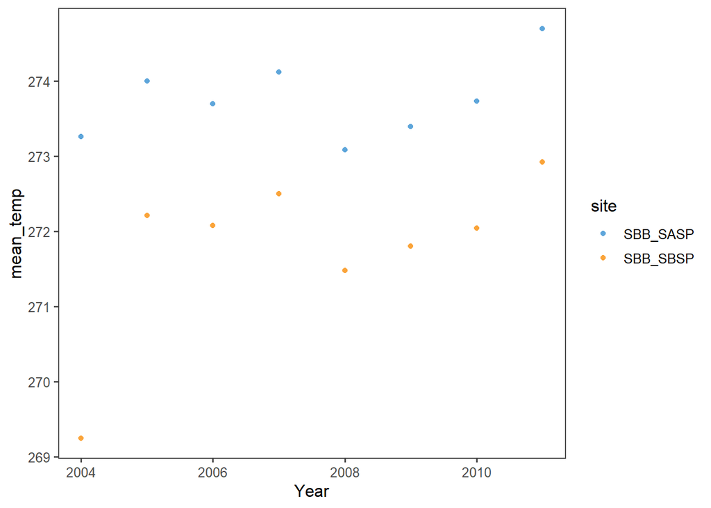

6. Write a function that makes line plots of monthly average temperature at each site for a given year. Use a for loop to make these plots for 2005 to 2010. Are monthly average temperatures at the Senator Beck Study Plot ever warmer than the Snow Angel Study Plot? Hint: https://ggplot2.tidyverse.org/reference/print.ggplot.html

The graphs below show the monthly average temperatures from 2005 to 2010. The SASP site is consistently warmer than the SBSP site.

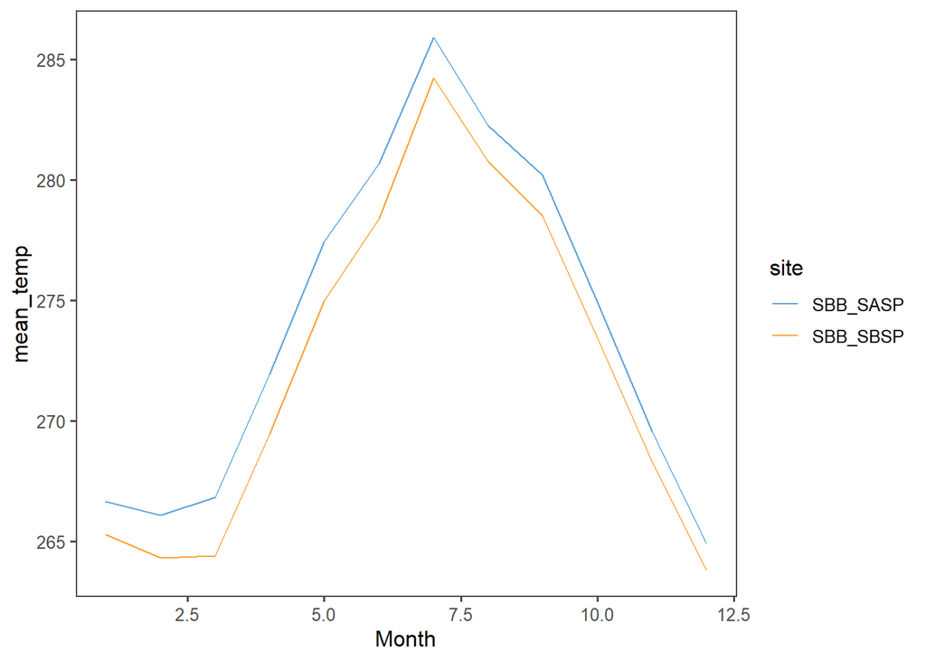

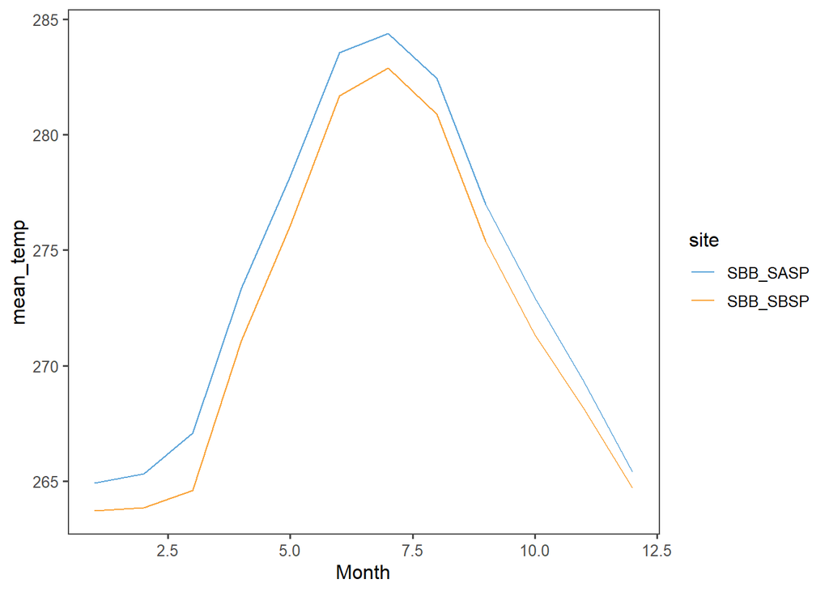

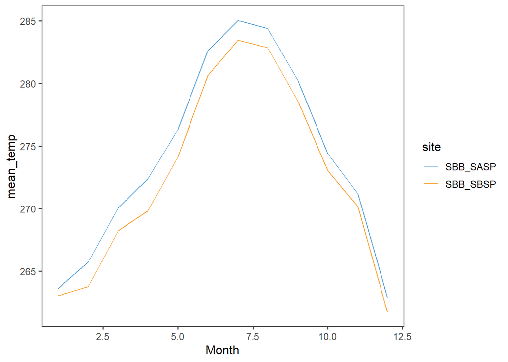

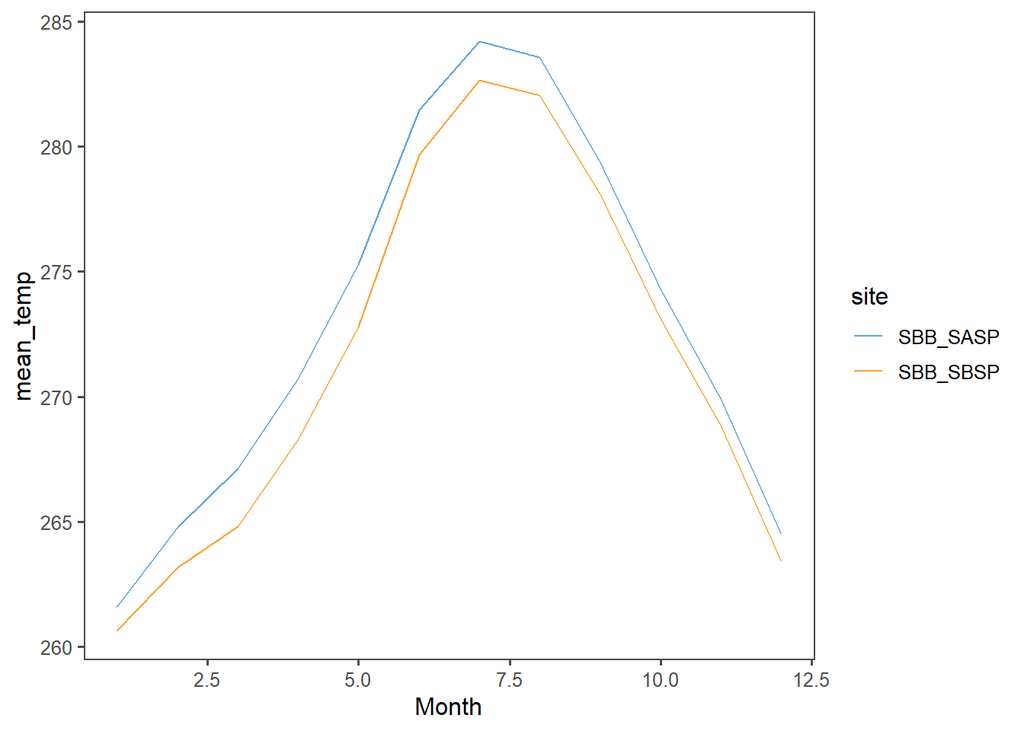

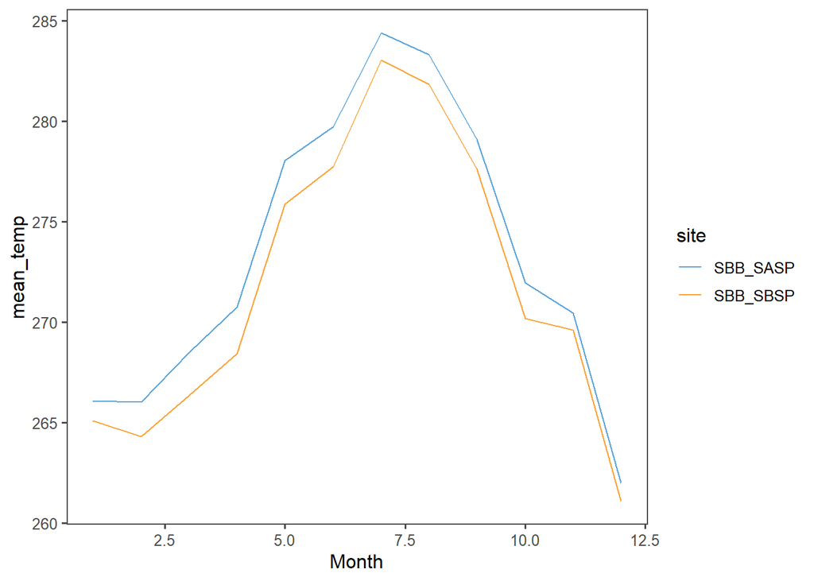

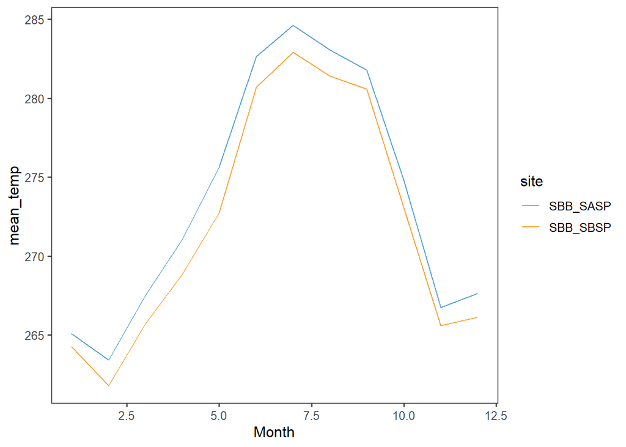

Bonus: Make a plot of average daily precipitation by day of year (averaged across all available years).

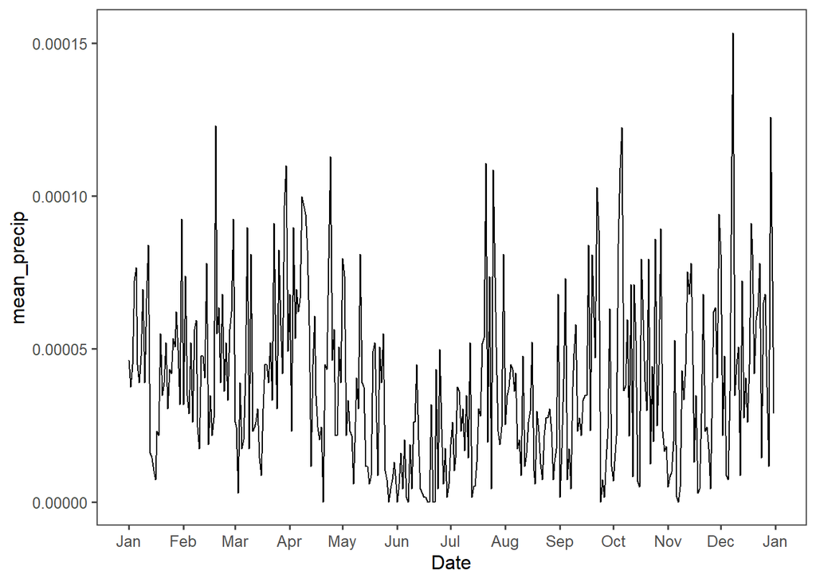

### Appendix

```r
library(rvest)
library(tidyverse)
library(lubridate)
library(readxl)

#Q1
site_url <- 'https://snowstudies.org/archived-data/'

#Read the web url
webpage <- read_html(site_url)

meteor_links <- webpage %>%
  html_nodes('a') %>%
  .[grepl('Forcing_Data',.)] %>%
  html_attr('href')

#Q2
#Grab only the name of the file by splitting out on forward slashes
splits <- str_split_fixed(meteor_links,'/',8)

#Keep only the 8th column
dataset <- splits[,8]

#generate a file list for where the data goes
file_names <- paste0('data/',dataset)

for(i in 1:2){
  download.file(meteor_links[i],destfile=file_names[i])
}

downloaded <- file.exists(file_names)

evaluate <- !all(downloaded)
#Q3
# this code grabs the variable names from the metadata pdf file
library(pdftools)
headers <- pdf_text('https://snowstudies.org/wp-content/uploads/2022/02/Serially-Complete-Metadata-text08.pdf') %>%
  readr::read_lines(.) %>%
  trimws(.) %>%
  str_split_fixed(.,'\\.',2) %>%
  .[,2] %>%
  .[1:26] %>%
  str_trim(side = "left")

#function to read in data files, clean them, keep relevant columns
data_reader <- function(file){
  name = str_split_fixed(file,'/',2)[,2] %>%
    gsub('_Forcing_Data.txt','',.)
  df <- read_fwf(file)
  names(df)<-c(headers[1:19])
  df <- df %>%
  select(-c(15:19)) %>%
  mutate(site = name)%>%
  mutate(DateTime = make_datetime(year, month, day, hour, minute, second))%>%
  select(c(16,7,10,15))%>%
  rename(precip_kgms=2, air_temp_K=3)
}

#Q4
meteor_data_full <- map_dfr(file_names,data_reader)

summary(meteor_data_full)
#Q5
meteor_yearly <- meteor_data_full %>%
  mutate(Year = year(DateTime)) %>%
  group_by(Year,site) %>%
  summarize(mean_temp = mean(air_temp_K,na.rm=T)) %>%
  filter(Year >2003)

ggplot(meteor_yearly,aes(x=Year,y=mean_temp,color=site)) +
  geom_point() +
  ggthemes::theme_few() +
  ggthemes::scale_color_few()
#Q6
monthly_mapper <-function(df, year){
  meteor_monthly <- df %>%
  mutate(Year = year(DateTime)) %>%
  mutate(Month= month(DateTime)) %>%
  group_by(Year,Month,site) %>%
  summarize(mean_temp = mean(air_temp_K,na.rm=T))%>%
  filter(Year == year)

x =  ggplot(data = meteor_monthly,aes(x=Month,y=mean_temp,color=site)) +
  geom_line() +
  ggthemes::theme_few() +
  ggthemes::scale_color_few()
print(x)
}

for (i in 2005:2010){
  monthly_mapper(meteor_data_full,i)
}

#bonus
meteor_daily<- meteor_data_full %>%
  filter(site=="SBB_SASP")%>%
  mutate(Month= month(DateTime))%>%
  mutate(Day = day(DateTime)) %>%
  group_by(Month,Day) %>%
  summarize(mean_precip = mean(precip_kgms,na.rm=T))%>%
  mutate(Date = paste(Month,Day,"2000"))

meteor_daily$Date <-mdy(meteor_daily$Date)

ggplot(data =meteor_daily, aes(x=Date, y=mean_precip))+
  scale_x_date(date_breaks = "1 month", date_labels =  "%b")+
  geom_line()+
  ggthemes::theme_few()
```